# Basics of Visualizations & Exploring Numerical Data

Applied Statistics

MTH-361A | Spring 2025 | University of Portland

January 31, 2025

# Objectives

- **Know the basics of visualizing numerical data**
- **Develop an understanding of different types of visualizing numerical data**
- **Introduce the language of the `ggplot2` package**
- **Activity: Visualize Numerical Data**

# Previously… (1/2)

**Types of Variables**

# Previously… (2/2)

**Chaining `dplyr` Verbs Using `%>%`**

**Load Packages**

```r
library(tidyverse)
```

**Define Data Frame as a Tibble**

```r
iris_tibble <- tibble(iris)
```

**Advanced Example:** The goal of this example is to transform the `iris` dataset by computing the ratio of `Petal.Length` to `Sepal.Length` for observations belonging to the “setosa” species.

```r
iris_tibble %>%
  # rule 1: choose only the "setosa" species
  filter(Species == "setosa") %>%
  # rule 2: pick the columns Sepal.Length and Petal.Length
  select(Sepal.Length,Petal.Length) %>%
  # rule 3: create a new column called length_ratio
  mutate(length_ratio = Petal.Length/Sepal.Length)
```

[output not shown]

# `tidyverse` Core Packages for Data Visualizations

`tidyverse` is a collection of packages suited for data processing and visualization.

[figure not shown]

Core packages specifically for data visualizations:

[figure not shown]

- `ggplot2` is a system for creating graphics, where you provide the data, specify how to map variables to plots, and it handles the details.

# Data Visualization Using `ggplot2`

**What is `ggplot2`?**

- **Overview:**
  - `ggplot2` is a powerful R package designed for data visualizations.
  - It is part of the `tidyverse` ecosystem.
- **Key Features:**
  - Intuitive grammar for graphics.
  - Intuitive syntax with layering using the operator `+`.

**Why use `ggplot2`?**

- **Ease of Use:** Clear, human-readable code.
- **Efficiency:** Built-in functions optimized for performance.
- **Consistency:** Works seamlessly with other `tidyverse` packages such as `dplyr` for data wrangling.
- **Data Frames and Beyond:** Works with data frames, tibbles, and databases.

# The Grammar for Graphics

**What is the Grammar of Graphics?**

- The Grammar of Graphics is a systematic approach to building visualizations by breaking down graphs into fundamental components.
- The `ggplot2` package in R is based on this framework, allowing for a highly customizable and layered approach to data visualization.

# Key Components of `ggplot2`

- **Data:** The dataset being visualized in tibble form.
- **Aesthetics (aes):** The mapping of data variables to visual properties like position, color, size, and shape.
- **Geometries (geom):** The type of plot (e.g., points, lines, bars) that represents the data.
- **Facets:** Splitting data into multiple panels for comparison.
- **Statistics (stat):** Computations applied to the data before plotting (e.g., smoothing, binning).
- **Coordinates (coord):** The system defining how data is mapped onto the plot (e.g., Cartesian, polar).
- **Themes:** Controls the overall appearance of the plot, such as background color, grid lines, and fonts.

# Example: `iris` Data Set Scatter Plots

**Plotting `iris` lengths**

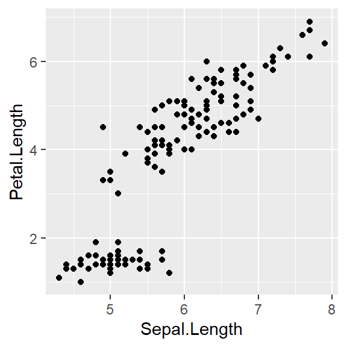

```r
# establish data and variables
ggplot(iris_tibble,
       aes(x = Sepal.Length,
           y = Petal.Length)) +
  # draw scatter plot
  geom_point() +
  # add theme layer
  theme_grey()
```

**Layered Approach**

- **Base layer:** `ggplot(data, aes(...))` defines the dataset and variables.
- **Geometric layers:** `+ geom_*()` specifies the type of plot.
- **Other layers:** `+ facet_*(), + coord_*(), + theme_*()` enhance the visualization.

$\star$ Note that the `+` operator here is used to “add” a layer, not adding numbers.

# Aesthetics

The `aes()` function maps data variables to visual properties like position, color, size, and shape.

**Plotting `iris` lengths by species**

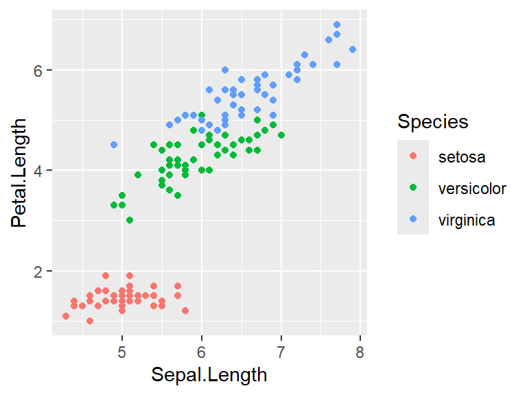

```r
# establish data and variables
ggplot(iris_tibble,
       aes(x = Sepal.Length,
           y = Petal.Length,
           color = Species)) +
  # draw scatter plot
  geom_point() +
  # add theme layer
  theme_grey()
```

**Common Aesthetics Mappings**

- **`x` and `y`:** Map variables to the horizontal and vertical axes.
- **`color`:** Assign colors to different categories.
- **`size`:** Control the size of points or lines based on a variable.
- **`shape`:** Change the shape of points according to a categorical variable.
- **fill:** Fill color of geometric objects of different categories.

$\star$ Note that the `aes()` function is called within the `ggplot()` function as the second argument.

# Layering

Using the `+` operator allows us to add layers to the plot, which is used for customizing the plot or adding more information.

**Plotting `iris` lengths by species with regression lines**

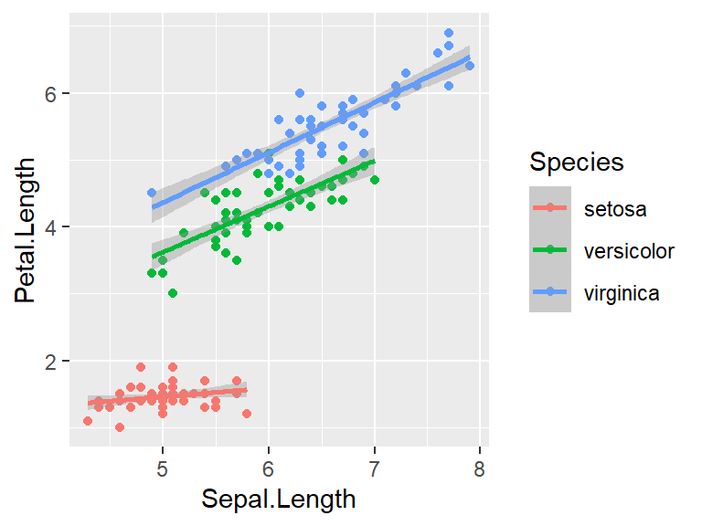

```r
# establish data and variables
ggplot(iris_tibble,
       aes(x = Sepal.Length,
           y = Petal.Length,
           color = Species)) +
  # draw scatter plot
  geom_point() +
  # add regression lines
  geom_smooth(method = 'lm',
              formula = y~x) +
  # add theme layer
  theme_grey()
```

**Layering to add more information**

- This example used the function `geom_smooth()`
- `geom_smooth()` fits a regression line to each group, then adds this line as a layer on the plot. *We will discuss more on this later*.

$\star$ **Key Idea:** All subsequent layers will inherit all information of the `aes()` variables defined in the `ggplot()` function.

# Common Geometries for Numerical Variables

| **Geom** | **Function** |
| --- | --- |
| `geom_point()` | Scatter plot for visualizing relationships between two numerical variables. |
| `geom_line()` | Line plot for trends over time or continuous sequences. |
| `geom_histogram()` | Histogram for visualizing the distribution of a single numerical variable. |
| `geom_dotplot()` | Shows each dot representing one observation in a distribution. |
| `geom_boxplot()` | Box plot for showing distributions and detecting outliers. |

$\star$ Be careful when defining variables in `aes()`. For example, `geom_histogram()` only requires an x-axis variable, as it plots the distribution of a single numerical variable.

# Example: `iris` Data Set Histograms

**Plotting the distribution of `iris` sepal lengths by species**

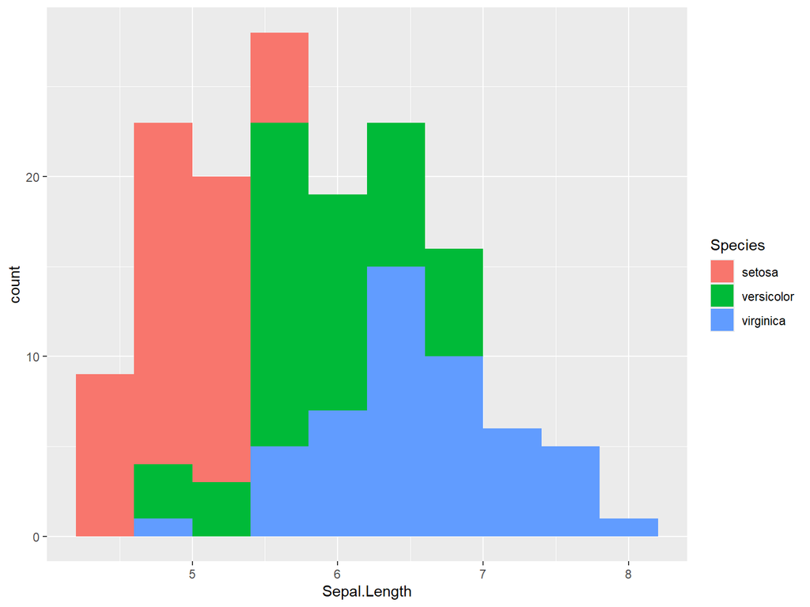

```r
# establish data and variables
ggplot(iris_tibble,
       aes(x = Sepal.Length,
           fill = Species)) +
  # draw histogram
  geom_histogram(bins=10) +
  # add theme layer
  theme_grey()
```

$\star$ The `geom_histogram()` function allows you to adjust the number of bins, affecting how the data is visualized. *We will discuss this later.*

# Basics of Exploring Numerical Data

**Variables**

- Types of Data: Continuous vs Discrete
- Descriptive Statistics: Measures of center (mean, median, mode) and spread (range, variance, standard deviation, IQR)

**Visualization Techniques**

- Dotplots: Understanding frequency distributions
- Histograms: Viewing shapes of distributions
- Boxplots: Detecting outliers and spread
- Scatterplots: Identifying relationships between variables

# Scatterplots

**Scatterplots** are useful for visualizing the relationship between *two numerical variables*.

*Example:*

- The variables `Sepal.Length` and `Petal.Length` in the `iris` data set appears to have a positive association. As `Sepal.Length` increases, `Petal.Length` also increases.

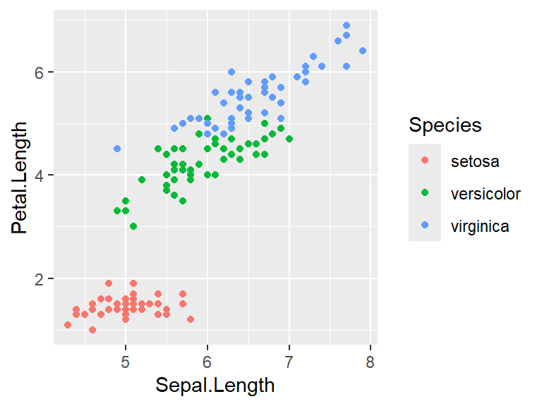

# Dot Plots

**Dot plots** are useful for visualizing one numerical variable. Darker colors represent areas where there are more observations.

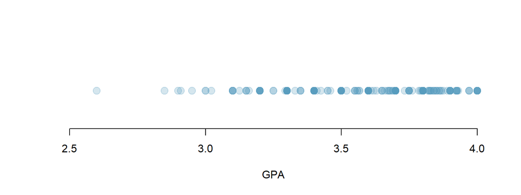

How would you describe the distribution of GPAs in this data set?

# Dot Plots and the Mean

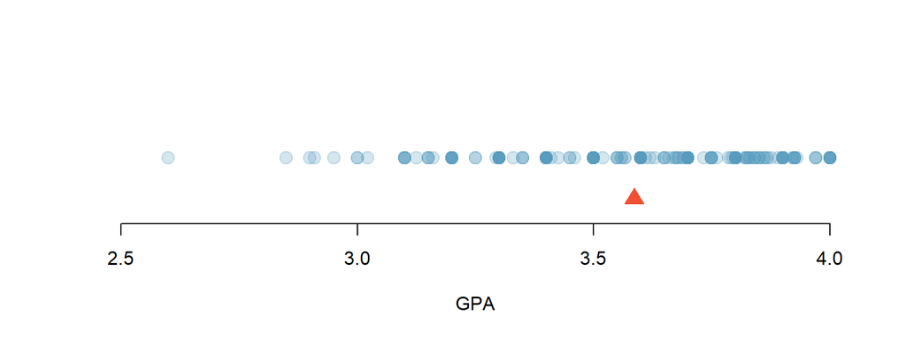

The **mean**, also called the **average** (marked with a triangle in the above plot), is one way to measure the center of a distribution of data.

**The mean GPA is 3.59.**

# Histograms

**Histograms** provide a view of the *data density*. Higher bars represent where the data are relatively more common.

- Histograms are especially convenient for describing the **shape** of the data distribution.
- The chosen **bin width** can alter the story the histogram is telling.

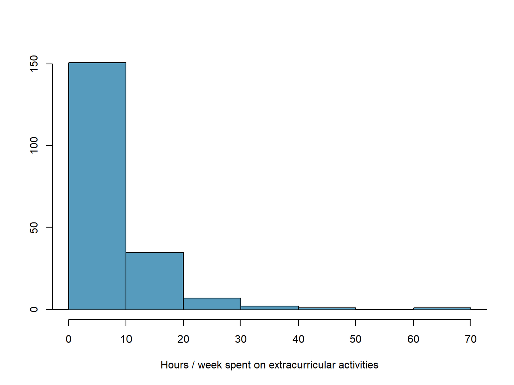

# Bin Width of Histograms

Which one(s) of these histograms are useful? Which reveal too much about the data? Which hide too much?

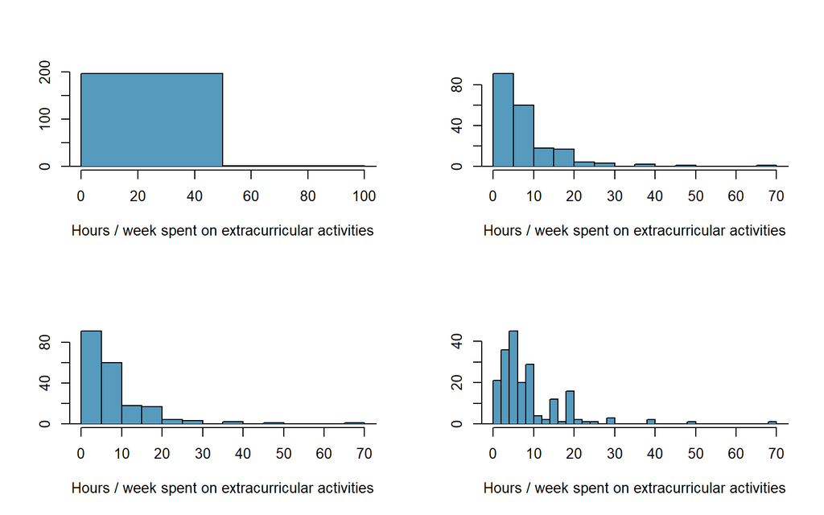

# Distribution Shapes: Modality

Does the histogram have a single prominent peak (**unimodal**), several prominent peaks (**bimodal/multimodal**), or no apparent peaks (**uniform**)?

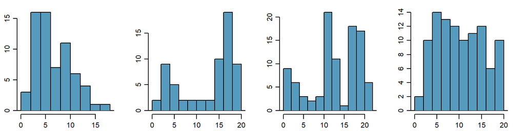

$\star$ **Note:** In order to determine modality, step back and imagine a smooth curve over the histogram – imagine that the bars are wooden blocks and you drop a limp spaghetti over them, the shape the spaghetti would take could be viewed as a smooth curve.

# Distribution Shapes: Skewness

Is the histogram **right skewed**, **left skewed**, or **symmetric**?

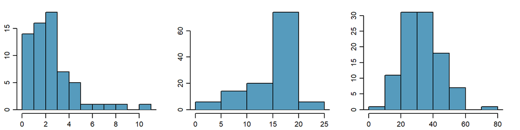

$\star$ **Note:** Histograms are said to be skewed to the side of the long tail.

# Commonly Observed Distribution Shapes

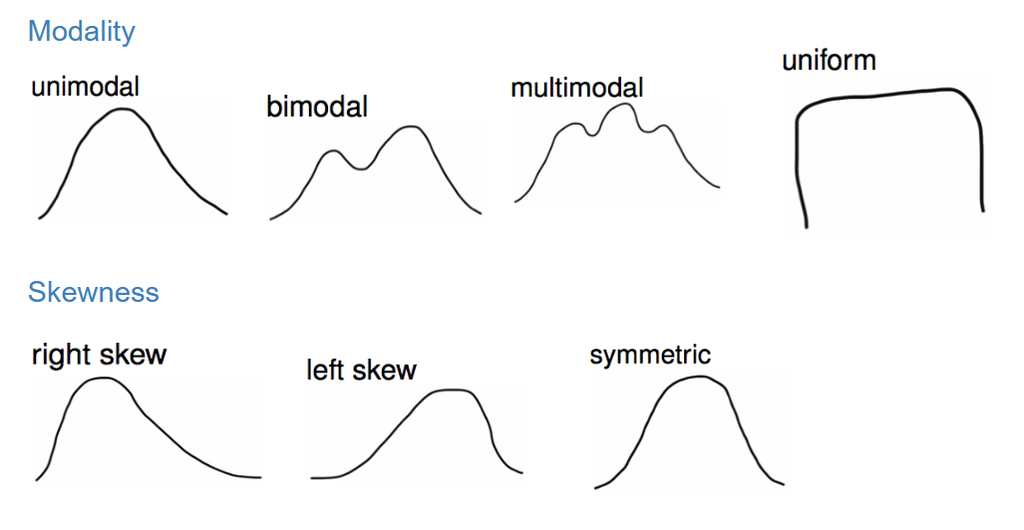

# Measures of Central Tendency

The **measures of central tendency** describe the central or typical value of a dataset, summarizing its distribution. The following are the common measures of central tendency:

- **Mean:** The arithmetic average of all data points, calculated as the sum of all values divided by the total number of values.
- **Median:** The middle value of an ordered dataset. If there is an even number of observations, the median is the average of the two middle values.
- **Mode:** The most frequently occurring value(s) in a dataset. A dataset may have one mode (unimodal), multiple modes (multimodal), or no mode if all values occur with equal frequency.

# Skewness and Measures Central Tendency (1/3)

**Mode** $<$ **Median** $<$ **Mean**

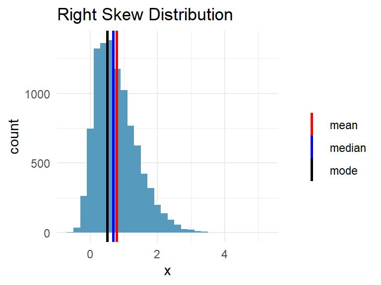

- If the distribution of data is **skewed to the right**, the **mode is less than the median, which is less than the mean**.

# Skewness and Measures Central Tendency (2/3)

**Mean** $<$ **Median** $<$ **Mode**

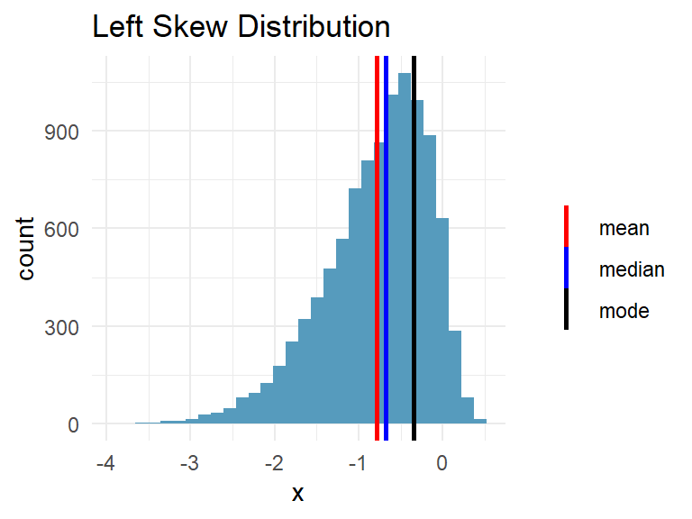

- If the distribution of data is **skewed to the left**, the **mean is less than the median, which is less than the mode**.

# Skewness and Measures Central Tendency (3/3)

**Mean** $=$ **Median** $=$ **Mode**

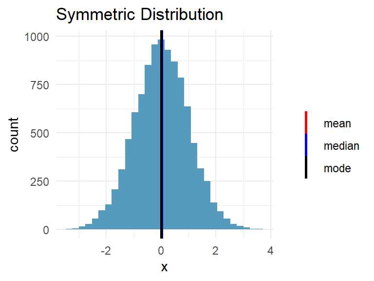

- If the distribution of data is **symmetric**, the **mean is roughly equal to the median, which is roughly equal to the mode**.

# Measures of Dispersion (Spread)

The **measures of dispersion** describes the variability of a numerical data. It is a way to quantify the uncertainty of a distribution. The following are the common measures of dispersion:

- **Variance:** The average squared deviation from the mean.
- **Standard Deviation:** The square root of the variance, providing a measure of spread in the same units as the data.
- **Range:** The difference between the maximum and minimum values.
- **Interquartile Range (IQR):** The difference between the 75th and 25th percentiles, capturing the spread of the middle 50% of the data.

# Making Sense of the Variance

**Common variance interpretations:**

- *Zero Variance:* All values are the same.
- *Low Variance:* Data points are close to the mean (consistent data).
- *High Variance:* Data points are spread out (greater variability).

**Example:** Order the following distributions from low to high variance.

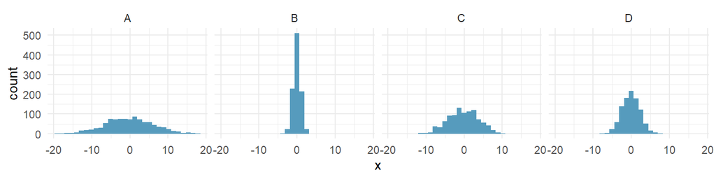

The above distributions are ordered from lowest to highest variance as follows: B, D, C, and A.

# Making Sense of the Standard Deviation

**Variance** gives a broader measure of spread, while **standard deviation** provides a more practical understanding of dispersion.

**Example:** Suppose we analyze the annual salaries of employees in two different companies:

| Company | $\overline{x}$ | $s^2$ | $s$ |
| --- | --- | --- | --- |
| A | $55K | $62.5K | $7.906K |
| B | $130K | $2250K | $47.434K |

- Even though Company B has higher salaries on average, its standard deviation is much larger, suggesting greater salary inequality.

$\star$ Standard deviation helps compare the spread of different distributions of the same units, which is directly interpretable as the typical deviation from the mean.

# Box Plots

The box in a **box plot** represents the middle 50% of the data, and the thick line in the box is the median.

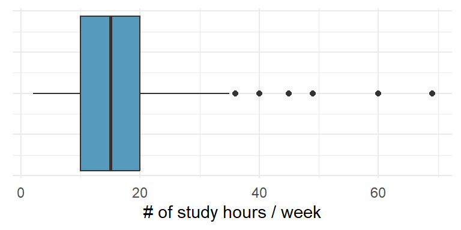

Box Plot of Study Hours

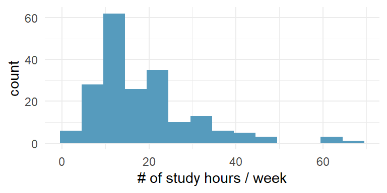

Histogram of Study Hours

$\star$ **Key Idea:** Box plots and histograms visualize numerical data, with histograms showing distribution shape, while box plots summarize spread and outliers, making them better for comparisons.

# Anatomy of Box Plots

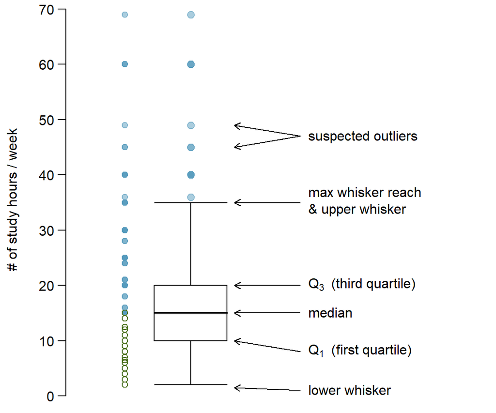

**Main Parts:**

# Computing the Whiskers

**Whiskers** of a box plot can extend up to $1.5 \times IQR$ away from the quartiles. The $1.5 \times \text{IQR}$ is arbitrary, and is considered an academic standard and the default in plotting box plots.

**Example:** Suppose that $Q_1 = 10$ and $Q_3 = 20$.

$$\text{IQR} = 20 - 10 = 10$$
$$\text{max upper whisker reach} = 20 + 1.5 \times
10 = 35$$
$$\text{max lower whisker
reach} = 10 - 1.5 \times 10 = -5$$

$\star$ A potential **outlier** is defined as an observation beyond the maximum reach of the whiskers. It is an observation that appears extreme relative to the rest of the data.

# More Boxplot and Dot Plot Examples

**Example:** The boxplot and stacked dot plot of the data set $7,1,2,4,6,3,2,7$ is shown below.

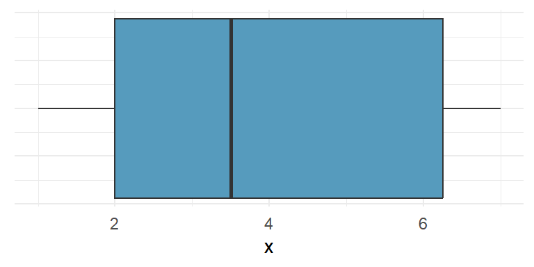

Box Plot

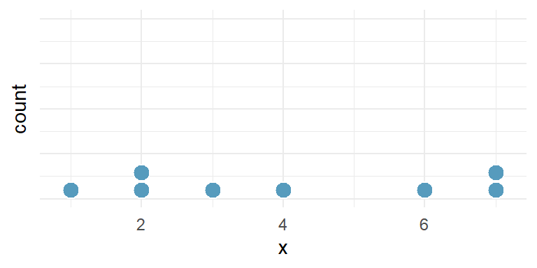

Stacked Dot Plot

$\star$ A dot plot is used instead of a histogram for convenience with the small discrete numbered dataset. The box plot shows no potential outliers, as all data points fall within the whiskers.

# Why Outliers are Important?

- Identify extreme skew in the distribution.
- Identify data collection and entry errors.
- Provide insight into interesting features of the data.

# Case Study 1

How would sample statistics such as mean, median, SD, and IQR of household income be affected if the largest value was replaced with $10 million? What if the smallest value was replaced with $10 million?

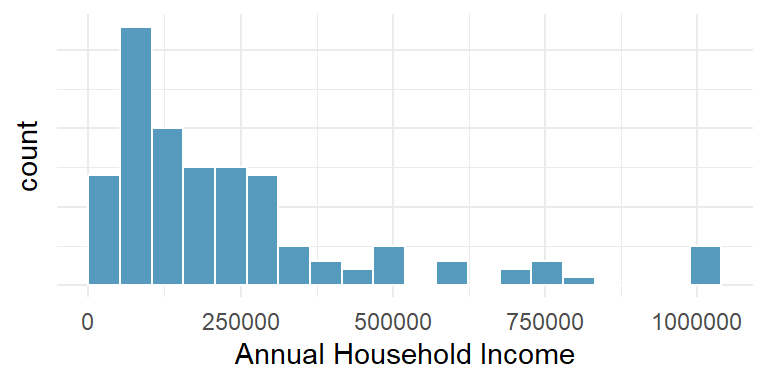

# Case Study 1: Extreme Observations

[output not shown]

# Robust Statistics

Median and IQR are more robust to skewness and outliers than mean and SD. Therefore,

- for skewed distributions it is often more helpful to use median and IQR to describe the center and spread
- for symmetric distributions it is often more helpful to use the mean and SD to describe the center and spread

# Activity: Visualize Numerical Data

1. Log-in to Posit Cloud and open the R Studio assignment *F 1/31 - Visualize Numerical Data*.
2. Make sure you are in the current working directory. Rename the `.Rmd` file by replacing `[name]` with your name using the format `[First name][Last initial]`. Then, open the `.Rmd` file.
3. Change the author in the YAML header.
4. Read the provided instructions.
5. Answer all exercise problems on the designated sections.

# References

Diez, D. M., Barr, C. D., & Çetinkaya-Rundel, M. (2012). *OpenIntro statistics* (4th ed.). OpenIntro. https://www.openintro.org/book/os/

Speegle, Darrin and Clair, Bryan. (2021). *Probability, statistics, and data: A fresh approach using r*. Chapman; Hall/CRC. https://probstatsdata.com/